# An example with simulated data

```r
library(sspm)
library(mgcv)
library(dplyr)
```

The following example shows the typical `sspm` workflow. We will use simulated data.

```r
sfa_boundaries
```

```
#> Simple feature collection with 4 features and 2 fields
#> Geometry type: MULTIPOLYGON
#> Dimension:     XY
#> Bounding box:  xmin: -64.18658 ymin: 46.00004 xmax: -46.6269 ymax: 60.84333
#> Geodetic CRS:  WGS 84
#>   sfa                       geometry               area
#> 1   4 MULTIPOLYGON (((-59.36453 5...  47575648300 [m^2]
#> 2   5 MULTIPOLYGON (((-55 53.75, ...  62857719164 [m^2]
#> 3   6 MULTIPOLYGON (((-49.9269 49... 178716060645 [m^2]
#> 4   7 MULTIPOLYGON (((-54.48779 4... 147799572836 [m^2]
```

```r
borealis_simulated
```

```
#> # A tibble: 1,800 × 8
#>    year_f sfa   weight_per_km2 temp_at_bottom lon_dec lat_dec   row uniqueID
#>    <fct>  <chr>          <dbl>          <dbl>   <dbl>   <dbl> <int> <chr>
#>  1 1995   7               14.7          1.31    -62.8    59.2     1 y1995s7r1
#>  2 1995   7              366.           0       -56.7    55.2     2 y1995s7r2
#>  3 1995   7              108.           0.982   -60.6    56.9     3 y1995s7r3
#>  4 1995   7               62.3          0       -58.0    56.4     4 y1995s7r4
#>  5 1995   7                0            0.698   -59.0    57.1     5 y1995s7r5
#>  6 1995   7                0            1.45    -58.8    56.3     6 y1995s7r6
#>  7 1995   7              236.           1.05    -51.1    50.7     7 y1995s7r7
#>  8 1995   7               68.2          0       -54.1    54.5     8 y1995s7r8
#>  9 1995   7               93.6          1.86    -54.9    53.7     9 y1995s7r9
#> 10 1995   7               25.4          1.74    -54.7    50.5    10 y1995s7r10
#> # ℹ 1,790 more rows
```

```r
predator_simulated
```

```
#> # A tibble: 10,200 × 7
#>    year_f sfa   weight_per_km2 lon_dec lat_dec   row uniqueID
#>    <fct>  <chr>          <dbl>   <dbl>   <dbl> <int> <chr>
#>  1 1995   7               9.90   -61.0    60.0     1 y1995s7r1
#>  2 1995   7             128.     -60.0    57.6     2 y1995s7r2
#>  3 1995   7             358.     -58.0    55.6     3 y1995s7r3
#>  4 1995   7               0      -58.0    55.9     4 y1995s7r4
#>  5 1995   7             103.     -60.5    57.2     5 y1995s7r5
#>  6 1995   7              57.3    -53.7    51.8     6 y1995s7r6
#>  7 1995   7              58.6    -53.6    50.7     7 y1995s7r7
#>  8 1995   7               0      -50.2    50.1     8 y1995s7r8
#>  9 1995   7               0      -54.6    54.0     9 y1995s7r9
#> 10 1995   7             131.     -52.8    51.0    10 y1995s7r10
#> # ℹ 10,190 more rows
```

```r
catch_simulated
```

```
#> # A tibble: 2,020 × 7
#>    year_f sfa   catch lon_dec lat_dec   row uniqueID
#>    <fct>  <chr> <dbl>   <dbl>   <dbl> <int> <chr>
#>  1 1991   4     2527.   -62.2    59.5     1 y1991s4r1
#>  2 1991   4     4194.   -61.0    58.0     2 y1991s4r2
#>  3 1991   4     7438.   -62.4    60.3     3 y1991s4r3
#>  4 1991   4        0    -58.2    55.2     4 y1991s4r4
#>  5 1991   4     3837.   -57.8    55.5     5 y1991s4r5
#>  6 1991   4     3196.   -58.6    56.3     6 y1991s4r6
#>  7 1991   4     3214.   -57.9    55.7     7 y1991s4r7
#>  8 1991   4        0    -56.4    54.4     8 y1991s4r8
#>  9 1991   4      539.   -58.9    55.6     9 y1991s4r9
#> 10 1991   4     4234.   -55.2    53.2    10 y1991s4r10
#> # ℹ 2,010 more rows
```

1. The first step of the `sspm` workflow is to create a `sspm_boundary` from an `sf` object, providing the `boundary` that delineates the boundary regions. The object can then be plotted with `spm_plot` (as can most `sspm` objects).

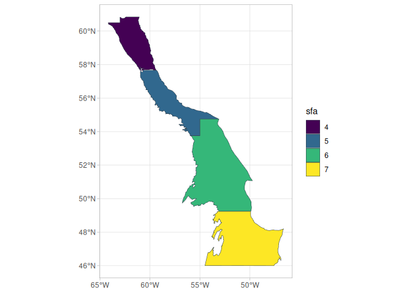

```r
bounds <- spm_as_boundary(boundaries = sfa_boundaries,
                          boundary = "sfa")

plot(bounds)
```

2. The second step consists in wrapping a `data.frame`, `tibble` or `sf` object into a `sspm_data` object, with a few other pieces of relevant information, such as the name, dataset type (biomass, predictor or catch, depending on the type of information contained), time column and coordinates column (i not `sf`) and unique row identifier. Here we wrap the borealis dataset that contains the biomass information.

```r
biomass_dataset <-
  spm_as_dataset(borealis_simulated, name = "borealis",
                 density = "weight_per_km2",
                 time = "year_f",
                 coords = c('lon_dec','lat_dec'),
                 uniqueID = "uniqueID")
```

```
#> ℹ  Casting data matrix into simple feature collection using columns: lon_dec, lat_dec
#> !  Warning: sspm is assuming WGS 84 CRS is to be used for casting
```

```r
biomass_dataset
```

```
#>
#> ‒‒ Dataset borealis ‒‒
#> →  [1800 rows, 9 columns]
#> →  Density : weight_per_km2
#> →  Time : year_f
```

3. We do the same with the predator data, which are of the predictor type.

```r
predator_dataset <-
  spm_as_dataset(predator_simulated, name = "all_predators",
                 density = "weight_per_km2",
                 time = "year_f",
                 coords = c("lon_dec", "lat_dec"),
                 uniqueID = "uniqueID")
```

```
#> ℹ  Casting data matrix into simple feature collection using columns: lon_dec, lat_dec
#> !  Warning: sspm is assuming WGS 84 CRS is to be used for casting
```

```r
predator_dataset
```

```
#>
#> ‒‒ Dataset all_predators ‒‒
#> →  [10200 rows, 8 columns]
#> →  Density : weight_per_km2
#> →  Time : year_f
```

4. The `sspm` workflow relies on the discretization of the boundary objects, the default method being voronoi tesselation.

```r
bounds_voronoi <- bounds %>%
  spm_discretize(method = "tesselate_voronoi",
                 with = biomass_dataset,
                 nb_samples = 30)
```

```
#> ℹ  Discretizing using method tesselate_voronoi
```

```r
bounds_voronoi
```

```
#>
#> ‒‒ Boundaries (Discrete) ‒‒
#> →  [4 rows, 3 columns]
#>   ★ Points — [120 features, 10 columns]
#>   ★ Patches — [85 features, 4 columns]
#> →  Column : sfa
#> →  Area : area_sfa
```

The other available method is `triangulate_delaunay` for delaunay triangulation. Here the `a` argument is used to set the size of the mesh (see `RTriangle::triangulate` for more details).

```r
## Not run
bounds_delaunay <- bounds %>%
  spm_discretize(method = "triangulate_delaunay", a = 1, q = 30)
bounds_delaunay
```

5. Plotting the object shows the polygons that have been created.

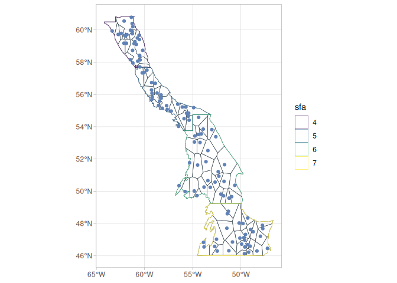

```r
plot(bounds_voronoi)
```

```r
## Not run
plot(bounds_delaunay)
```

6. The results of the discretization can also be explored with `spm_patches()` and `spm_points()`.

```r
spm_patches(bounds_voronoi)
```

```
#> Simple feature collection with 85 features and 3 fields
#> Geometry type: POLYGON
#> Dimension:     XY
#> Bounding box:  xmin: -64.18658 ymin: 46.00004 xmax: -46.6269 ymax: 60.84489
#> Geodetic CRS:  WGS 84
#> # A tibble: 85 × 4
#>    sfa   patch_id patch_area                                            geometry
#>  * <fct> <fct>        [km^2]                                       <POLYGON [°]>
#>  1 4     P1            3328. ((-63.11402 59.66424, -62.83338 60.43615, -63 60.8…
#>  2 4     P2            4099. ((-62.00856 58.53059, -61.78999 58.61768, -61.4823…
#>  3 4     P3            3308. ((-61.80265 59.43396, -61.97171 59.81804, -62.0892…
#>  4 4     P4            6814. ((-61.48231 59.06057, -61.78999 58.61768, -61.1115…
#>  5 4     P5            1677. ((-59.37831 57.67423, -59.43377 57.71988, -59.4892…
#>  6 4     P6            2282. ((-59.70893 58.16354, -60.11445 58.34307, -60.2929…
#>  7 4     P7            9080. ((-60.07796 59.21579, -60.11318 59.24152, -60.1409…
#>  8 4     P8            3003. ((-62.7581 59.09816, -62.49637 59.37714, -62.69224…
#>  9 4     P9           10478. ((-62.08921 59.41056, -61.97171 59.81804, -61.8026…
#> 10 4     P10           1601. ((-61.38138 58.03343, -61.11151 58.34397, -61.7899…
#> # ℹ 75 more rows
```

```r
spm_points(bounds_voronoi)
```

```
#> Simple feature collection with 120 features and 9 fields
#> Geometry type: POINT
#> Dimension:     XY
#> Bounding box:  xmin: -63.35709 ymin: 46.12884 xmax: -47.23827 ymax: 60.77991
#> Geodetic CRS:  WGS 84
#> # A tibble: 120 × 10
#> # Groups:   sfa [4]
#>    year_f weight_per_km2 temp_at_bottom lon_dec lat_dec   row uniqueID
#>  * <fct>       [kg/km^2]          <dbl>   <dbl>   <dbl> <int> <chr>
#>  1 1995               0           0.676   -49.0    47.6    16 y1995s7r16
#>  2 1995               0           0.808   -60.2    57.3    46 y1995s5r46
#>  3 1995               0           0       -60.0    57.4    47 y1995s5r47
#>  4 1996               0           1.36    -60.5    57.7    81 y1996s6r81
#>  5 1996           14731.          2.46    -55.5    54.8    86 y1996s6r86
#>  6 1996            9112.          3.47    -56.1    55.2   104 y1996s5r104
#>  7 1996            5442.          1.74    -55.8    50.0   109 y1996s5r109
#>  8 1996           19154.          0.747   -54.8    53.1   112 y1996s5r112
#>  9 1996           11333.          3.43    -47.2    46.5   120 y1996s5r120
#> 10 1996            2746.          1.51    -55.9    54.5   123 y1996s4r123
#> # ℹ 110 more rows
#> # ℹ 3 more variables: geometry <POINT [°]>, sfa <fct>, area_sfa [km^2]
```

7. The next step in this workflow is to smooth the variables to be used in the final `sspm` model, by using spatial-temporal smoothers, by passing each dataset through `spm_smooth`. Here we first smooth `weight_per_km2` as well as `temp_at_bottom`. Note that the boundary column `sfa` can be used in the formula as the data will be first joined to the provided boundaries.

```r
biomass_smooth <- biomass_dataset %>%
  spm_smooth(weight_per_km2 ~ sfa + smooth_time(by = sfa) +
               smooth_space() +
               smooth_space_time(),
             boundaries = bounds_voronoi,
             family=tw)%>%
  spm_smooth(temp_at_bottom ~ smooth_time(by=sfa, xt = NULL) +
               smooth_space() +
               smooth_space_time(xt = NULL),
             family=gaussian)
```

```
#> ℹ  Fitting formula: weight_per_km2 ~ sfa + smooth_time(by = sfa) + smooth_space() + smooth_space_time() for dataset 'borealis'
#> ℹ  Note:  response variable temp_at_bottom is NOT a biomass density variable
#> ℹ  Fitting formula: temp_at_bottom ~ smooth_time(by = sfa, xt = NULL) + smooth_space() + smooth_space_time(xt = NULL) for dataset 'borealis'
```

```r
biomass_smooth
```

```
#>
#> ‒‒ Dataset borealis (Mapped) ‒‒
#> →  [1801 rows, 12 columns]
#> →  Density : weight_per_km2
#> →  Time : year_f
#> →  Smoothed data : [2040 rows, 8 columns]
#>    ★ Smoothed vars: temp_at_bottom — weight_per_km2
```

8. The smoothed results for any smoothed variables (listed in “smoothed vars” above) can be easily plotted. Here the 4 panels represent 4 different patches in the same SFA. The panels show a very similar pattern due to the nature of the simulated data we are using. The data points are actually different, but the differences are not noticeable in this example case.

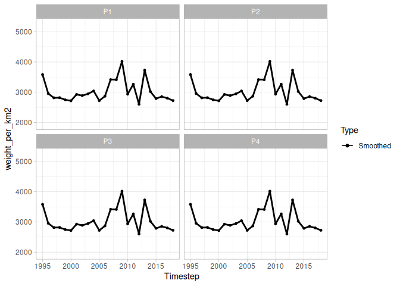

```r
plot(biomass_smooth, var = "weight_per_km2", log = FALSE, interval = T)
```

You can also make a spatial plot

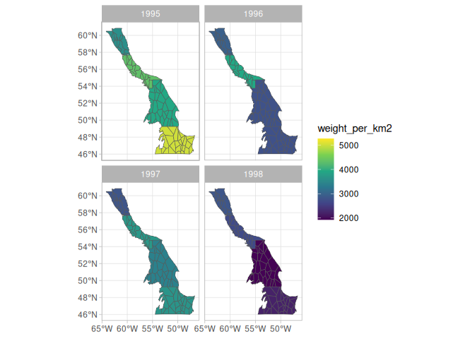

```r
plot(biomass_smooth, var = "weight_per_km2", use_sf = TRUE)
```

9. We also smooth the `weight_per_km2` variable in the predator data.

```r
predator_smooth <- predator_dataset %>%
  spm_smooth(weight_per_km2 ~ smooth_time() + smooth_space(),
             boundaries = bounds_voronoi,
             drop.unused.levels = F, family=tw, method= "fREML")
```

```
#> ℹ  Fitting formula: weight_per_km2 ~ smooth_time() + smooth_space() for dataset 'all_predators'
```

```r
predator_smooth
```

```
#>
#> ‒‒ Dataset all_predators (Mapped) ‒‒
#> →  [10201 rows, 11 columns]
#> →  Density : weight_per_km2
#> →  Time : year_f
#> →  Smoothed data : [3400 rows, 7 columns]
#>    ★ Smoothed vars: weight_per_km2
```

10. Before we assemble the full model with our newly smoothed data, we need to deal with the catch data. We first load the dataset.

```r
catch_dataset <-
  spm_as_dataset(catch_simulated, name = "catch_data",
                 biomass = "catch",
                 time = "year_f",
                 uniqueID = "uniqueID",
                 coords = c("lon_dec", "lat_dec"))
```

```
#> ℹ  Casting data matrix into simple feature collection using columns: lon_dec, lat_dec
#> !  Warning: sspm is assuming WGS 84 CRS is to be used for casting
```

```r
catch_dataset
```

```
#>
#> ‒‒ Dataset catch_data ‒‒
#> →  [2020 rows, 8 columns]
#> →  Biomass : catch
#> →  Time : year_f
```

11. We then need to aggregate this data. This illustrate using the `spm_aggregate` functions. Here we use `spm_aggregate_catch`:

```r
biomass_smooth_w_catch <-
  spm_aggregate_catch(biomass = biomass_smooth,
                      catch = catch_dataset,
                      biomass_variable = "weight_per_km2",
                      catch_variable = "catch",
                      fill = mean)
```

```
#> ℹ  Offsetting biomass with catch data using columns: weight_per_km2, catch
```

```r
biomass_smooth_w_catch
```

```
#>
#> ‒‒ Dataset borealis (Mapped) ‒‒
#> →  [1801 rows, 12 columns]
#> →  Density : weight_per_km2
#> →  Time : year_f
#> →  Smoothed data : [2040 rows, 13 columns]
#>    ★ Smoothed vars: temp_at_bottom — weight_per_km2
#>    ★ Vars with catch: weight_per_km2_borealis_with_catch
```

12. Once data has been smoothed, we can assemble a `sspm` model object, using one dataset of type biomass, one dataset of type predictor and (optionnaly) a dataset of type catch.

```r
sspm_model <- sspm(biomass = biomass_smooth_w_catch,
                   predictors = predator_smooth)
```

```
#> ℹ  Joining smoothed data from all datasets
```

```r
sspm_model
```

```
#>
#> ‒‒ Model (2 datasets) ‒‒
#> →  Smoothed data : [2040 rows, 14 columns]
#>    ★ Smoothed vars: temp_at_bottom — weight_per_km2_all_predators — weight_per_km2_borealis
#>    ★ Vars with catch: weight_per_km2_borealis_with_catch
```

13. Before fitting the model, we must split data into test/train with `spm_split`.

```r
sspm_model <- sspm_model %>%
  spm_split(year_f %in% c(1990:2017))

sspm_model
```

```
#>
#> ‒‒ Model (2 datasets) ‒‒
#> →  Smoothed data : [2040 rows, 15 columns] / [1955 train, 85 test]
#>    ★ Smoothed vars: temp_at_bottom — weight_per_km2_all_predators — weight_per_km2_borealis
#>    ★ Vars with catch: weight_per_km2_borealis_with_catch
```

14. To fit the model, we might be interested in including lagged values. This is done with `spm_lag`.

```r
sspm_model <- sspm_model %>%
  spm_lag(vars = c("weight_per_km2_borealis",
                   "weight_per_km2_all_predators"),
          n = 1)

sspm_model
```

```
#>
#> ‒‒ Model (2 datasets) ‒‒
#> →  Smoothed data : [2040 rows, 17 columns] / [1955 train, 85 test]
#>    ★ Smoothed vars: temp_at_bottom — weight_per_km2_all_predators — weight_per_km2_borealis
#>    ★ Vars with catch: weight_per_km2_borealis_with_catch
#>    ★ lagged vars: weight_per_km2_all_predators_lag_1 — weight_per_km2_borealis_lag_1
```

15. We can now fit the final spm model with `spm`.

```r
sspm_model_fit <- sspm_model %>%
  spm(log_productivity ~ sfa +
        weight_per_km2_all_predators_lag_1 +
        smooth_space(by = weight_per_km2_borealis_lag_1) +
        smooth_space(),
      family = mgcv::scat)
```

```
#> ℹ  Fitting SPM formula: log_productivity ~ sfa + weight_per_km2_all_predators_lag_1 + smooth_space(by = weight_per_km2_borealis_lag_1) + smooth_space()
```

```r
sspm_model_fit
```

```
#>
#> ‒‒ Model fit ‒‒
#> →  Smoothed data : [2040 rows, 17 columns] / [1955 train, 85 test]
```

It is possible to access the GAM fit object in order to look at it in more details and, for example, evaluate the goodness of fit.

```r
gam_fit <- spm_get_fit(sspm_model_fit)
summary(gam_fit)
```

```
#>
#> Family: Scaled t(6.902,0.162)
#> Link function: identity
#>
#> Formula:
#> log_productivity ~ sfa + weight_per_km2_all_predators_lag_1 +
#>     s(patch_id, k = 30, bs = "mrf", xt = list(penalty = pen_mat_space),
#>         by = weight_per_km2_borealis_lag_1) + s(patch_id, k = 30,
#>     bs = "mrf", xt = list(penalty = pen_mat_space))
#>
#> Parametric coefficients:
#>                                      Estimate Std. Error t value Pr(>|t|)
#> (Intercept)                         6.757e-01  8.383e-02   8.060 1.36e-15 ***
#> sfa5                                6.994e-02  8.035e-02   0.870   0.3842
#> sfa6                                2.792e-02  9.794e-02   0.285   0.7756
#> sfa7                                7.556e-02  1.051e-01   0.719   0.4723
#> weight_per_km2_all_predators_lag_1 -2.220e-05  8.982e-06  -2.471   0.0136 *
#> ---
#> Signif. codes:  0 '***' 0.001 '**' 0.01 '*' 0.05 '.' 0.1 ' ' 1
#>
#> Approximate significance of smooth terms:
#>                                             edf Ref.df      F p-value
#> s(patch_id):weight_per_km2_borealis_lag_1 20.48     30 40.041  <2e-16 ***
#> s(patch_id)                               16.54     29  7.926  <2e-16 ***
#> ---
#> Signif. codes:  0 '***' 0.001 '**' 0.01 '*' 0.05 '.' 0.1 ' ' 1
#>
#> R-sq.(adj) =  0.656   Deviance explained =   42%
#> -REML = -363.8  Scale est. = 1         n = 1870
```

You can also use the summary method.

```r
summary(sspm_model_fit, biomass = "weight_per_km2_borealis")
```

```
#> ── Productivity ────────────────────────────────────────────────────────────────
#>   sfa      mean       min       max         sd
#> 1   4 0.9874073 0.7369743  1.104953 0.09318704
#> 2   5 0.9921537 0.6238932  1.251561 0.13445643
#> 3   6 1.0137909 0.7003419  1.259051 0.11266712
#> 4   7 1.2543014 0.6472841 10.872099 1.34612892
#> ── Biomass density ─────────────────────────────────────────────────────────────
#>   sfa               mean                min                max       sd
#> 1   4 2971.628 [kg/km^2] 2859.994 [kg/km^2] 3073.849 [kg/km^2]  43.7213
#> 2   5 3150.301 [kg/km^2] 2793.433 [kg/km^2] 3641.974 [kg/km^2] 110.9342
#> 3   6 3265.644 [kg/km^2] 2268.377 [kg/km^2] 4243.372 [kg/km^2] 505.8465
#> 4   7 3249.529 [kg/km^2] 1576.912 [kg/km^2] 4231.252 [kg/km^2] 197.4388
#> ── Biomass (with catch) ────────────────────────────────────────────────────────
#>   sfa          mean              min           max       sd
#> 1   4 12862864 [kg] 4587242.793 [kg] 32213576 [kg]  8762561
#> 2   5 11679183 [kg] 5923299.183 [kg] 24133214 [kg]  4615176
#> 3   6 19474547 [kg] 3699560.763 [kg] 66685162 [kg] 10285854
#> 4   7 17841803 [kg]    4729.845 [kg] 60821339 [kg] 11405000
```

16. Plotting the object produces a actual vs predicted plot (with TEST/TRAIN data highlighted.

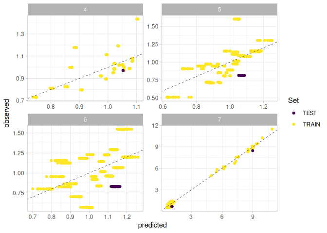

```r
plot(sspm_model_fit, train_test = TRUE, scales = "free")
```

17. We can also extract the predictions.

```r
preds <- predict(sspm_model_fit)
head(preds)
```

```
#> Simple feature collection with 6 features and 6 fields
#> Geometry type: POLYGON
#> Dimension:     XY
#> Bounding box:  xmin: -64.18658 ymin: 59.66424 xmax: -62.83338 ymax: 60.80996
#> Geodetic CRS:  WGS 84
#>      pred_log      pred patch_id year_f sfa      patch_area
#> 1 -0.07177659 0.9307388       P1   1995   4 3328.183 [km^2]
#> 2 -0.15263458 0.8584434       P1   1996   4 3328.183 [km^2]
#> 3  0.01861213 1.0187864       P1   1997   4 3328.183 [km^2]
#> 4  0.05328728 1.0547326       P1   1998   4 3328.183 [km^2]
#> 5  0.05321252 1.0546538       P1   1999   4 3328.183 [km^2]
#> 6  0.07145163 1.0740662       P1   2000   4 3328.183 [km^2]
#>                         geometry
#> 1 POLYGON ((-63.11402 59.6642...
#> 2 POLYGON ((-63.11402 59.6642...
#> 3 POLYGON ((-63.11402 59.6642...
#> 4 POLYGON ((-63.11402 59.6642...
#> 5 POLYGON ((-63.11402 59.6642...
#> 6 POLYGON ((-63.11402 59.6642...
```

We can also get the predictions for biomass by passing the biomass variable name.

```r
biomass_preds <- predict(sspm_model_fit, biomass = "weight_per_km2_borealis")
head(biomass_preds)
```

```
#> Simple feature collection with 6 features and 8 fields
#> Geometry type: POLYGON
#> Dimension:     XY
#> Bounding box:  xmin: -64.18658 ymin: 59.66424 xmax: -62.83338 ymax: 60.80996
#> Geodetic CRS:  WGS 84
#> # A tibble: 6 × 9
#>   year_f patch_id sfa   patch_area biomass_with_catch   biomass
#>    <dbl> <fct>    <fct>     [km^2]               [kg]      [kg]
#> 1   1995 P1       4          3328.                NA        NA
#> 2   1996 P1       4          3328.          10233654. 10229237.
#> 3   1997 P1       4          3328.          10018409. 10013992.
#> 4   1998 P1       4          3328.           9874763.  9866687.
#> 5   1999 P1       4          3328.           9890433.  9885271.
#> 6   2000 P1       4          3328.           9817927.  9813511.
#> # ℹ 3 more variables: biomass_density_with_catch [kg/km^2],
#> #   biomass_density [kg/km^2], geometry <POLYGON [°]>
```

We can also predict the biomass one step ahead.

```r
biomass_one_step <- predict(sspm_model_fit, biomass = "weight_per_km2_borealis",
                            next_ts = TRUE)
head(biomass_one_step)
```

```
#> Simple feature collection with 6 features and 5 fields
#> Geometry type: POLYGON
#> Dimension:     XY
#> Bounding box:  xmin: -64.18658 ymin: 57.66667 xmax: -59.36453 ymax: 60.80996
#> Geodetic CRS:  WGS 84
#> # A tibble: 6 × 6
#>   patch_id year_f sfa     biomass patch_area                            geometry
#>   <fct>     <dbl> <fct>      [kg]     [km^2]                       <POLYGON [°]>
#> 1 P1         2019 4      9526287.      3328. ((-63.11402 59.66424, -62.83338 60…
#> 2 P2         2019 4     11746452.      4099. ((-62.00856 58.53059, -61.78999 58…
#> 3 P3         2019 4      9473790.      3308. ((-61.80265 59.43396, -61.97171 59…
#> 4 P4         2019 4     19543484.      6814. ((-61.48231 59.06057, -61.78999 58…
#> 5 P5         2019 4      4806023.      1677. ((-59.37831 57.67423, -59.43377 57…
#> 6 P6         2019 4      6552791.      2282. ((-59.70893 58.16354, -60.11445 58…
```

18. We can produce an array of plots, as timeseries or as spatial plots

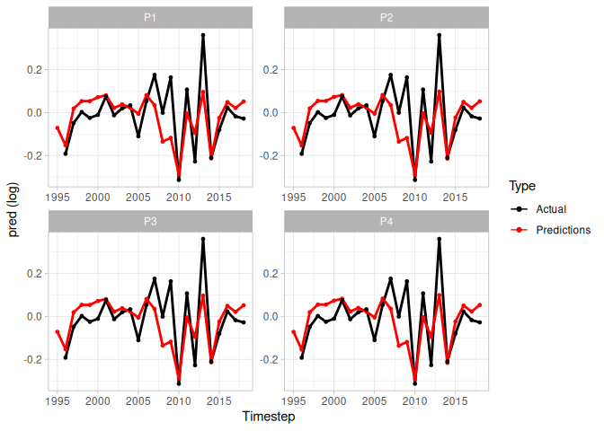

```r
plot(sspm_model_fit, log = T, scales = 'free')
```

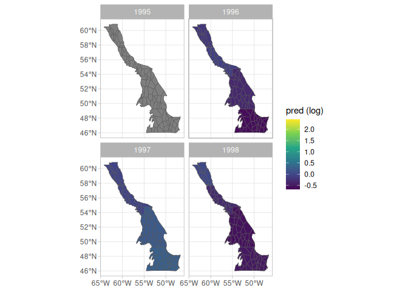

```r
plot(sspm_model_fit, log = T, use_sf = TRUE)
```

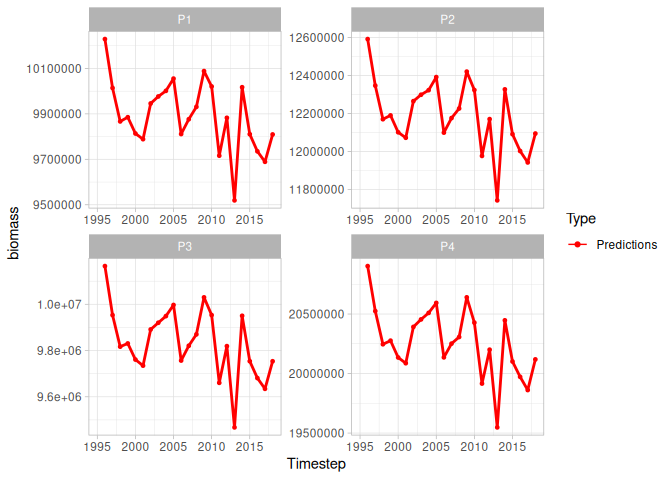

```r
plot(sspm_model_fit, biomass = "weight_per_km2_borealis",  scales = "free")
```

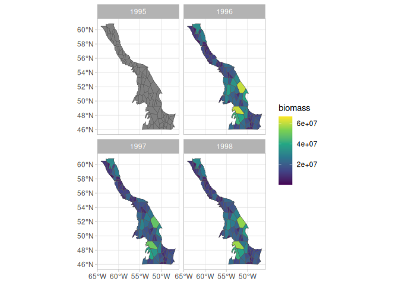

```r
plot(sspm_model_fit, biomass = "weight_per_km2_borealis", use_sf = TRUE)
```

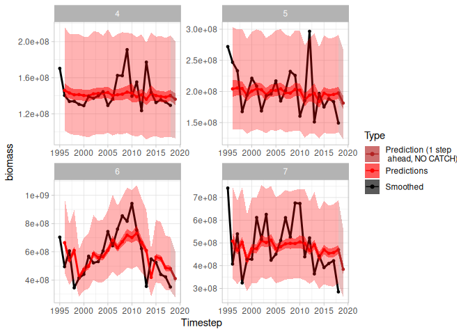

```r
plot(sspm_model_fit, biomass = "weight_per_km2_borealis",
     next_ts = TRUE, aggregate = TRUE, scales = "free",
     smoothed_biomass = TRUE, interval = T)
```